# The Moat

How Healthcare Providers Build and Defend Market Power

Health Economics and Policy

# The Moat

## Every Player in Healthcare Has Built a Moat

**The Core Tension**

Every healthcare provider has built a **moat** — a barrier that controls who enters the market, who delivers care, and at what price.

These moats can **protect patients** (quality assurance, safety standards) OR **extract rents** (inflated prices, restricted access). The tension between these two forces defines supply-side health economics.

**Today’s agenda — mapping the moats:**

1. **Building the first moat:** How physicians control the supply of doctors
2. **Inside the castle:** How physicians use their market power
3. **The fortress:** How hospitals built an even bigger moat
4. **Widening the moat:** What happens when providers consolidate

## A Preview of the Empirical Landscape

The papers you’ll read this semester explore these themes:

**Physician Markets**

- How do incentives shape physician behavior? (Clemens & Gottlieb)
- What happens when Medicare changes prices? (Alexander)
- How does practice style evolve? (Molitor, Currie et al.)

**Hospital Markets**

- Why are hospital prices so variable? (Cooper et al.)
- What happens after mergers? (Gaynor et al., Beaulieu et al.)
- Does vertical integration help or hurt? (Baker et al., Richards et al.)

## From Questions to Moats

Healthcare providers don’t compete in a free market. They’ve built moats — and the first moat was built by physicians themselves, through the longest training pipeline in any profession.

# Building the First Moat

How Physicians Control the Supply of Doctors

## The Longest Moat: 11+ Years of Training

**Medical school**

- Entry is competitive: ~50% accepted to at least one school
- Time-to-degree varies by country
  - US/Canada: Bachelor’s degree first (8+ years total)
  - Europe: Direct from high school (6 years)
- **Expensive:** $200k-$260k for four years (2024 US)
- European training often heavily subsidized

**Residency**

- 3-7 years of on-the-job training after medical school
- “July effect” (US) / “August killing season” (UK)
  - Medical errors spike when new residents arrive

[figure not shown]

The physician training pipeline

## The Hidden Cost: Physician Work Hours

**The Demands:**

- Residents work **60+ hours/week**
- On-call residents could work up to **30 consecutive hours**

**The Legislation (2003):**

- Cap of 80 hours/week for US residents
- No change in patient mortality
- Many residents still exceed 80 hours but report only 80

**The Tradeoff:**

- Fewer hours → less fatigue → fewer errors
- But also → more handoffs → potential for communication failures

**The Evidence (Brigham & Women’s ICU, 2004):**

Randomized experiment comparing traditional hours (80 hrs/week) vs. shorter hours (60 hrs/week):

**Traditional-Hour Group Had:**

- **36% more** serious medical errors
- **21% more** medication errors
- **5.6× more** diagnostic errors
- Senior physicians intercepted most serious errors

> The moat demands long training — but exhaustion is the price physicians (and their patients) pay.

## Physicians Sacrifice a Decade Before Earning Returns

Unlike most careers, returns to medicine are **back-loaded**:

- Medical school & residency = **negative earnings** for 7-11 years
- Direct costs + opportunity costs
- Those who choose medicine must be **patient**

**The Selection Effect**

Only individuals with high **discount factors** (patient people who value future income) will find the NPV of medicine attractive.

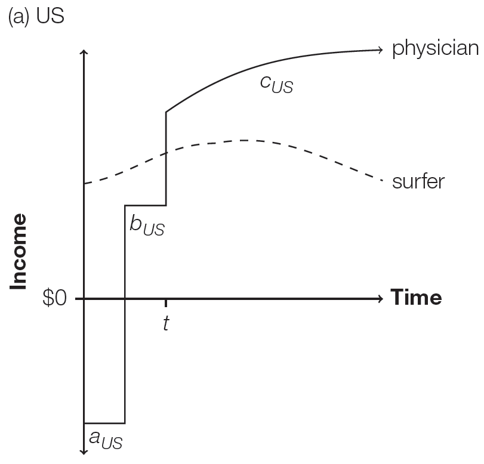

Returns to medical training over time

## The Crossover: When the Investment Pays Off

**Show R Code**

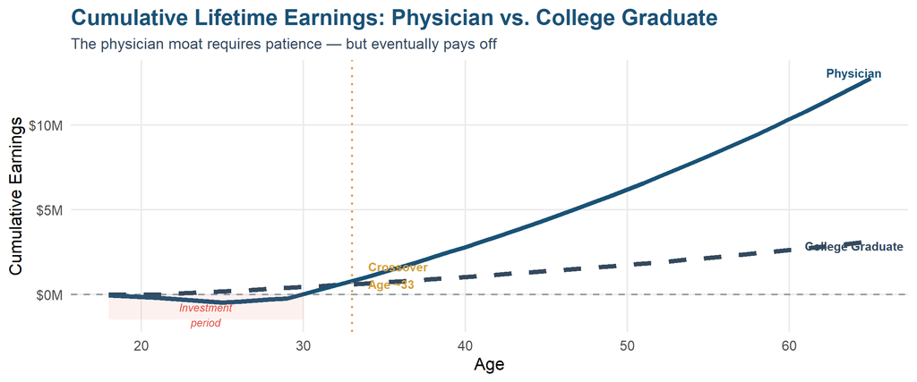

Figure 1: Physician earnings vs. college graduate: the back-loaded payoff

```r
# Conceptual lifecycle earnings data
ages <- 18:65

# College graduate: starts earning at 22, steady growth
college_earnings <- case_when(
  ages < 22 ~ 0,
  TRUE ~ 45000 * (1.02)^(ages - 22)
)

# Physician: negative during training (debt), then high earnings
physician_earnings <- case_when(
  ages < 22 ~ -50000,    # Undergrad (tuition)
  ages < 26 ~ -70000,    # Medical school (tuition + living)
  ages < 30 ~ 60000,     # Residency/fellowship
  TRUE ~ 250000 * (1.02)^(ages - 30)
)

# Cumulative earnings
college_cumulative <- cumsum(college_earnings)
physician_cumulative <- cumsum(physician_earnings)

lifecycle_data <- tibble(
  age = rep(ages, 2),
  cumulative = c(college_cumulative, physician_cumulative),
  career = rep(c("College Graduate", "Physician"), each = length(ages))
)

crossover_index <- which(physician_cumulative > college_cumulative)[1]
crossover_age <- ages[crossover_index]
crossover_y <- physician_cumulative[crossover_index] / 1e6

label_data <- lifecycle_data %>%
  group_by(career) %>%
  slice_tail(n = 1) %>%
  ungroup() %>%
  mutate(
    label_x = age - 1,
    label_y = (cumulative / 1e6) + ifelse(career == "Physician", 0.35, -0.25)
  )

ggplot(lifecycle_data, aes(x = age, y = cumulative / 1e6, color = career, linetype = career)) +
  geom_line(linewidth = 2) +
  geom_text(
    data = label_data,
    aes(x = label_x, y = label_y, label = career),
    fontface = "bold",
    size = 4,
    show.legend = FALSE
  ) +
  geom_hline(yintercept = 0, linetype = "dashed", color = slate_gray, alpha = 0.5) +
  geom_vline(xintercept = crossover_age, linetype = "dotted", color = warm_gold, linewidth = 1) +
  annotate("text", x = crossover_age + 1, y = crossover_y + 0.35,
           label = paste0("Crossover\nAge ~", crossover_age),
           color = warm_gold, fontface = "bold", size = 4, hjust = 0) +
  annotate("rect", xmin = 18, xmax = 30, ymin = -1.5, ymax = 0,
           fill = accent_coral, alpha = 0.08) +
  annotate("text", x = 24, y = -1.2, label = "Investment\nperiod",
           color = accent_coral, size = 3.5, fontface = "italic") +
  scale_color_manual(values = c("College Graduate" = slate_gray, "Physician" = primary_blue), name = "") +
  scale_linetype_manual(values = c("College Graduate" = "dashed", "Physician" = "solid"), name = "") +
  scale_y_continuous(labels = label_dollar(suffix = "M")) +
  labs(
    title = "Cumulative Lifetime Earnings: Physician vs. College Graduate",
    subtitle = "The physician moat requires patience — but eventually pays off",
    x = "Age", y = "Cumulative Earnings"
  ) +
  theme_health_econ(base_size = 16) +
  theme(legend.position = "none")
```

## The Math Says: Medicine Is Still Worth the Wait

**Net present value** calculates the value of all future income streams from today’s perspective:

$$NPV = \sum_{t=0}^{T} \delta^t I(t)$$

**The discount factor** $\delta$

- Measures how much less you value future vs. present income
- $\delta \in (0, 1)$: small if impatient, large if patient
- Equivalently: $\delta = \frac{1}{1+r}$ where $r$ is the discount rate

**Example:**

- $\delta = 0.90$ corresponds to $r = 11\%$
- Very patient people have high $\delta$, low $r$
- They’re willing to wait for the payoff

**Consider** two careers: Physician (P) vs. Alternative (C)

The **internal rate of return** $r^*$ is the discount rate that equalizes NPV:

$$\sum_{t=0}^{T} \frac{I_P(t) - I_C(t)}{(1 + r^*)^t} = 0$$

**The Puzzle**

IRR in medicine is typically **11-14%** — far above market interest rates!

- Also true for dentists, lawyers, specialists
- If returns are so high, why haven’t more people entered, pushing IRR down?

**Graduate Students: Measuring Physician Rents**

Bhattacharya (2005) estimates a structural model of physician career choice. After accounting for selection on ability and risk preferences, the IRR to medicine falls to ~7-8% — still above the risk-free rate, suggesting regulatory rents persist.

## The Moat Explains the Premium

**19th century:** Anyone could become a doctor — no regulation

**American Medical Association (1847):**

- Prerequisites for medical school
- 4 years of medical education
- License required to practice
- 1910 Flexner Report shut down “low-quality” schools

**Result:** Fewer schools, fewer students, higher returns

**Additional barriers:**

- Caps on medical school class sizes
- Arduous licensing for international graduates
- Scope-of-practice limits on NPs, PAs

**The tradeoff:**

- Consumers pay **above competitive prices**
- Physicians earn **monopoly rents**
- But barriers ensure **quality** (in theory)

## The Moat Protects Quality — But At a Cost

**Show R Code**

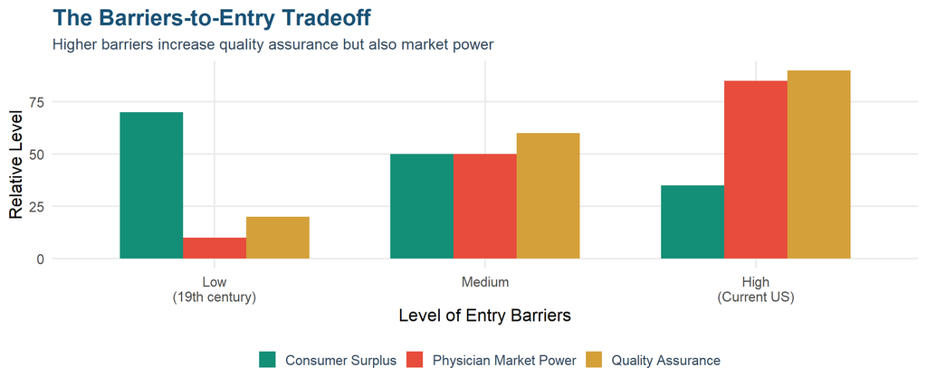

Figure 2: Barriers to entry create both quality assurance and market power

```r
# Create conceptual diagram data
tradeoff_data <- tibble(
  barrier_level = c("Low\n(19th century)", "Medium", "High\n(Current US)"),
  quality_assurance = c(20, 60, 90),
  market_power = c(10, 50, 85),
  consumer_surplus = c(70, 50, 35)
) %>%
  mutate(barrier_level = factor(barrier_level, levels = c("Low\n(19th century)", "Medium", "High\n(Current US)")))

tradeoff_long <- tradeoff_data %>%
  pivot_longer(cols = c(quality_assurance, market_power, consumer_surplus),
               names_to = "metric", values_to = "value") %>%
  mutate(metric = case_when(
    metric == "quality_assurance" ~ "Quality Assurance",
    metric == "market_power" ~ "Physician Market Power",
    metric == "consumer_surplus" ~ "Consumer Surplus"
  ))

ggplot(tradeoff_long, aes(x = barrier_level, y = value, fill = metric)) +
  geom_col(position = "dodge", width = 0.7) +
  scale_fill_manual(values = c(secondary_teal, accent_coral, warm_gold), name = "") +
  labs(
    title = "The Barriers-to-Entry Tradeoff",
    subtitle = "Higher barriers increase quality assurance but also market power",
    x = "Level of Entry Barriers",
    y = "Relative Level"
  ) +
  theme_health_econ(base_size = 16) +
  theme(legend.position = "bottom")
```

**Papers to Read**

**Alexander & Schnell (2019):** What happens when NPs get independent prescriptive authority? **Dillender et al. (2022):** How do occupational licensing rules affect the healthcare labor market?

## The Moat Test

**The Golden Rule of Supply-Side Health Economics**

*“For any healthcare market, ask: Who built the moat, and who does it protect?”*

**Three questions to diagnose market power:**

1. **What’s the moat?** (Licensing? Geography? Information? Capital requirements?)
2. **Who benefits?** (Patients through quality? Providers through rents? Both?)
3. **What would happen if the moat were lowered?** (Better access? Lower quality? Both?)

*Every paper we read this semester is really about a moat — who built it, whether it helps patients, and what happens when policy changes the walls.*

## From Moats to Behavior

The moat controls who gets in. But once inside, how do physicians use their position? Information asymmetry gives them power over patients — and how they wield it depends on incentives.

# Inside the Castle

How Physicians Use Their Market Power

## Inside the Castle: Physicians Don’t Always Act in Your Interest

**The Ideal**

Patients trust physicians to act as **perfect agents** for their health — doctors’ primary concern should be patient well-being, not financial gain.

**But are doctors always perfect agents?**

- Information asymmetry creates opportunity for **physician-induced demand**
- Payment systems create **incentives** that may conflict with patient welfare
- Fear of lawsuits drives **defensive medicine**

## When the Moat Creates Perverse Incentives

**The setup:**

- Patients cannot assess whether an extra test or procedure is necessary
- Doctors have financial incentives to prescribe more services

**Empirical evidence:**

- When reimbursement rates change, prescription patterns change
- Volume responds to price signals in ways consistent with PID

**Papers to Read**

**Clemens & Gottlieb (2014):** Do physicians’ financial incentives affect treatment and health? **Alexander (2020):** Unintended consequences of paying doctors to reduce costs

**Graduate Students: Testing for PID**

Gruber & Owings (1996) exploit the decline in fertility as a demand shock to OB/GYNs. They find physicians substitute toward C-sections — evidence consistent with demand inducement. Identification relies on area-level fertility changes as an exogenous shock to physician income.

## Defensive Medicine

**The Problem**

Doctors fearful of lawsuits may overprescribe marginally-useful procedures.

**Mello et al. (2010):** Medical liability system costs **$55.6 billion annually** in the US

**Forms of defensive medicine:**

- Ordering extra tests “just in case”
- Referring to specialists unnecessarily
- Avoiding high-risk patients

**The tradeoff:**

- Some defensive medicine may actually help patients
- But much of it is waste
- Hard to distinguish ex ante

## Practice Style: Where Does It Come From?

**Currie, MacLeod, and Van Parys (2016):** Practice style matters for patient outcomes

**Molitor (2018):** When cardiologists move, their practice style evolves

- Physicians’ treatment patterns converge toward local norms
- ~60% of geographic variation in care is due to physician practice style
- Suggests practice style is **learned**, not fixed

**Implication**

If practice style is malleable, policy can potentially influence it through:

- Training programs
- Peer effects
- Payment incentives

## Discrimination in Medical Care

**Types of discrimination:**

**Taste-based:**

- Preferential treatment for certain groups
- Conscious or unconscious bias
- Always inefficient

**Statistical:**

- Using group characteristics to infer individual traits
- May be efficient if medically justified
- Example: Hypertension treatment differs by race

**Shulman et al. (1999):** Audit study with actors

- Same script, background, symptoms
- Only difference: race of “patient”
- Result: Physicians less likely to recommend standard treatment for Black patients

## From Physicians to Hospitals

Physicians built the first moat through licensing and training. Hospitals built an even bigger one — out of concrete, capital, and geography.

# The Fortress

How Hospitals Became the Most Expensive Buildings in America

## From Deathtraps to Fortresses: The Hospital Transformation

**19th century hospitals** were dangerous places:

- Higher mortality rates than staying home
- No understanding of germ theory

**Late 1800s innovations:**

- Germ theory of disease
- Antiseptic techniques
- Anesthesia
- X-ray technology

**Result:** Hospitals became places of healing, not dying

## Hill-Burton and the Hospital Boom

**Hill-Burton Act (1946):**

- Federal funding for hospital construction
- Hospitals receiving money had to provide free/low-cost care to the poor

**Result:** More hospitals, more beds, more access

**But then technology changed the game:**

- Recovery times shortened
- Insurers incentivized shorter stays
- Trend toward outpatient care

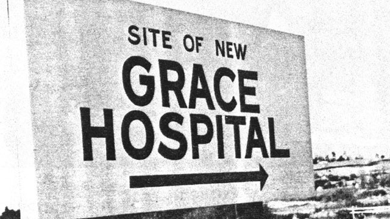

Hill-Burton funded hospital construction nationwide

## The Shift to Outpatient Care

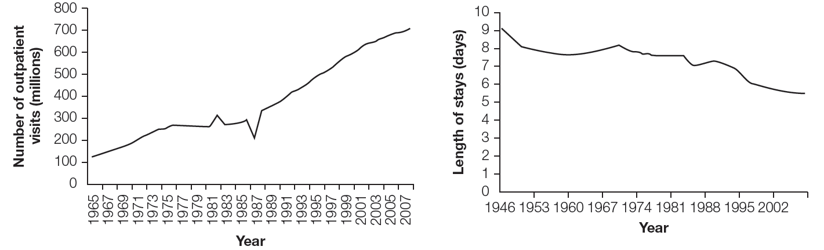

Trends in outpatient utilization and length of stay

**Key Trends**

- Increased outpatient visits
- Decreased inpatient length of stay
- Technology + payment policy driving the shift

## Hospital-Physician Relationships

**Three modes:**

| Mode | Description | Example |
| --- | --- | --- |
| Physicians’ Workbench | Doctors not employed by hospital | Majority of US hospitals |
| Direct Employment | Hospital employs physicians | UK NHS, US “hospitalists” |
| Physician-Owned | Doctors own the hospital | Japan, some US specialty hospitals |

**The tradeoffs:**

- Where does physician loyalty lie — hospital or patient?
- Employed physicians may be easier to coordinate
- Independent physicians may overuse hospital resources

## Volume-Outcome Relationship

**Show R Code**

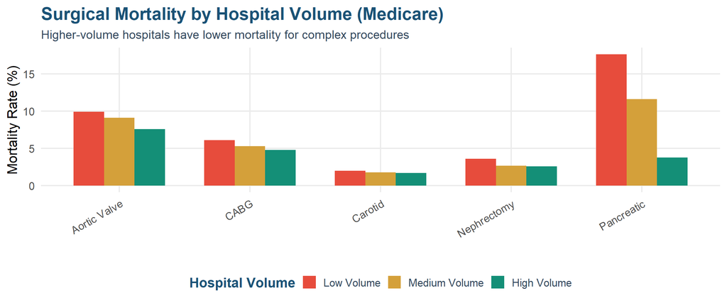

Figure 3: Surgical mortality decreases with hospital volume

```r
# Create the dataframe
volume_data <- tibble(
  Procedure = c("CABG", "Aortic Valve", "Carotid", "Pancreatic", "Nephrectomy"),
  `Low Volume` = c(6.1, 9.9, 2.0, 17.6, 3.6),
  `Medium Volume` = c(5.3, 9.1, 1.8, 11.6, 2.7),
  `High Volume` = c(4.8, 7.6, 1.7, 3.8, 2.6)
) %>%
  pivot_longer(cols = -Procedure, names_to = "Volume", values_to = "Mortality") %>%
  mutate(Volume = factor(Volume, levels = c("Low Volume", "Medium Volume", "High Volume")))

ggplot(volume_data, aes(x = Procedure, y = Mortality, fill = Volume)) +
  geom_col(position = "dodge", width = 0.7) +
  scale_fill_manual(values = c(accent_coral, warm_gold, secondary_teal), name = "Hospital Volume") +
  labs(
    title = "Surgical Mortality by Hospital Volume (Medicare)",
    subtitle = "Higher-volume hospitals have lower mortality for complex procedures",
    x = "", y = "Mortality Rate (%)"
  ) +
  theme_health_econ(base_size = 16) +
  theme(axis.text.x = element_text(angle = 30, hjust = 1))
```

## Learning-by-Doing vs. Selective Referral

**Two hypotheses for the volume-outcome relationship:**

**Learning-by-doing:**

- High volume → good outcomes
- Practice makes perfect
- Hospitals/teams improve with experience

**Selective referral:**

- Good outcomes → high volume
- Reputation attracts patients
- Better hospitals get more referrals

**McGrath et al. (2000):**

- Hospital experience matters more than individual physician experience
- **Teams** of medical workers collaborate on surgeries
- Individual physician experience is less impactful

**Implication:** Think about the hospital, not just the surgeon

**Graduate Students: Identifying the Volume-Outcome Relationship**

The endogeneity problem: do high-volume hospitals have better outcomes because practice makes perfect (learning-by-doing), or because better hospitals attract more patients (selective referral)? Gaynor, Seider & Vogt (2005) use distance as an instrument for volume to separate these channels.

## Competition Between Fortresses Can Backfire

**Standard economics:** Competition → lower prices, higher quality

**But healthcare is different:**

- Insurance hides prices from consumers
- Patients don’t choose hospitals — physicians refer them
- **Medical arms race hypothesis:** Hospitals compete for physicians by acquiring expensive technology

**The Result**

Competition among hospitals for physicians can lead to:

- Redundant technology
- Overconsumption
- Higher costs without quality improvement

## Hospital Prices Are Negotiated, Not Set

**A chest x-ray in California (2004):**

- Hospital A: $120
- Hospital B: $1,519
- **Same service, 12x price difference**

**Why?**

- Nobody pays “chargemaster” prices
- Hospitals and insurers negotiate rates
- Prices vary with relative **bargaining power**
- The same hospital may get different rates from different insurers

**Papers to Read**

**Cooper et al. (2019):** “The Price Ain’t Right” — hospital prices and spending on the privately insured

## Nonprofit vs. For-Profit Hospitals

**US hospital landscape:**

- 75% of private hospitals are nonprofit (2009)
- Nonprofits are tax-exempt
- Donors receive tax deductions

**But nonprofits face constraints:**

- Cannot sell stock
- Cannot distribute profits to owners
- Restricted to “charitable” activities

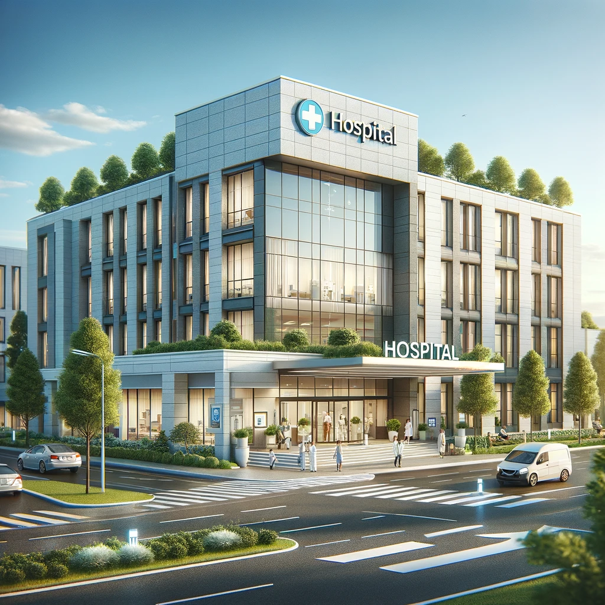

Most US hospitals are nonprofit

**Theories for nonprofit existence:**

1. Altruistic entrepreneurs prefer mission over profits
2. Government fails to help those in need
3. Donors trust nonprofits more
4. Nonprofits are for-profits in disguise (profits = higher wages)

## Who Pays for Uncompensated Care?

**Last-resort laws:** Hospitals must treat all ER patients regardless of ability to pay

**When patients can’t pay:**

- **Uncompensated care** = charges not covered by payments/insurance
- Someone has to absorb these costs

**Cost-shifting mechanisms:**

- Rich patients pay for poor patients’ care (**cross-subsidization**)
- Private insurers pay higher rates than Medicare/Medicaid
- The “hidden tax” on private insurance

## The Consolidation Wave Is Accelerating

**Show R Code**

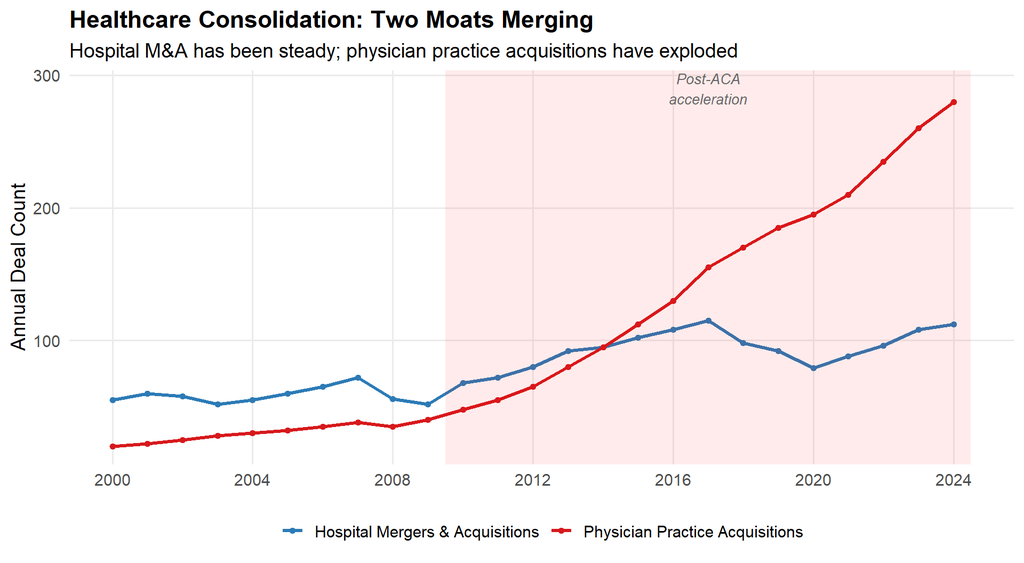

Figure 4: Healthcare consolidation has accelerated dramatically since 2010

```r
library(tidyverse)

# Conceptual data based on published merger trends
# Sources: Irving Levin Associates, Kaufman Hall, AMA Physician Practice Benchmark
consolidation_data <- tibble(
  year = rep(2000:2024, 2),
  type = rep(c("Hospital Mergers & Acquisitions",
               "Physician Practice Acquisitions"), each = 25),
  count = c(
    # Hospital M&A (approximate annual deal counts)
    55, 60, 58, 52, 55, 60, 65, 72, 56, 52,
    68, 72, 80, 92, 95, 102, 108, 115, 98, 92,
    79, 88, 96, 108, 112,
    # Physician practice acquisitions (approximate, rising steeply)
    20, 22, 25, 28, 30, 32, 35, 38, 35, 40,
    48, 55, 65, 80, 95, 112, 130, 155, 170, 185,
    195, 210, 235, 260, 280
  )
)

ggplot(consolidation_data, aes(x = year, y = count, color = type)) +
  geom_line(linewidth = 1.2) +
  geom_point(size = 1.5) +
  annotate("rect", xmin = 2009.5, xmax = 2024.5, ymin = -Inf, ymax = Inf,
           alpha = 0.08, fill = "red") +
  annotate("text", x = 2017, y = 290,
           label = "Post-ACA\nacceleration",
           fontface = "italic", size = 3.5, color = "gray40") +
  scale_color_manual(values = c("Hospital Mergers & Acquisitions" = "#2c7bb6",
                                "Physician Practice Acquisitions" = "#d7191c")) +
  scale_x_continuous(breaks = seq(2000, 2024, 4)) +
  labs(x = NULL, y = "Annual Deal Count",
       color = NULL,
       title = "Healthcare Consolidation: Two Moats Merging",
       subtitle = "Hospital M&A has been steady; physician practice acquisitions have exploded") +
  theme_minimal(base_size = 14) +
  theme(
    legend.position = "bottom",
    plot.title = element_text(face = "bold"),
    panel.grid.minor = element_blank()
  )
```

## From Competition to Consolidation

Physicians have their moat. Hospitals have theirs. What happens when they combine? Consolidation is the story of moats merging — and the evidence on what it does to prices and quality is remarkably consistent.

# Widening the Moat

What Happens When Providers Consolidate

## Most Patients Have Fewer Hospital Choices Than They Think

**Hospitals operate in concentrated markets:**

- Strict barriers to entry (buildings, technology, staff)
- Few firms (oligopoly)
- Services are not perfect substitutes (differentiated products)

**Herfindahl-Hirschman Index (HHI):**

$$HHI = \sum_i s_i^2$$

where $s_i$ = market share of firm $i$

- HHI close to 1 → highly concentrated (few firms)
- HHI close to 0 → competitive (many firms)

## Hospital Markets Are More Concentrated Than You Think

**Show R Code**

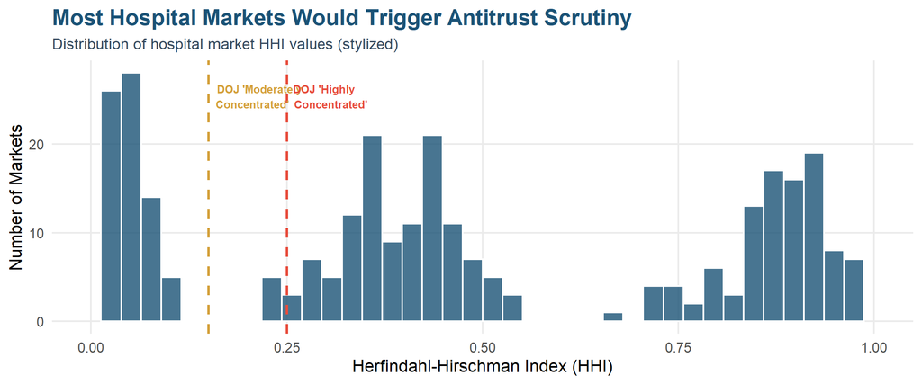

Figure 5: Distribution of hospital market HHI (conceptual)

```r
set.seed(6320)
# Simulate HHI distribution for ~300 hospital markets
# Based on stylized facts: most markets are concentrated
hhi_values <- c(
  rbeta(80, 2, 5) * 0.15,        # Some competitive markets
  rbeta(120, 3, 2) * 0.4 + 0.15, # Moderately concentrated
  rbeta(100, 5, 2) * 0.45 + 0.55 # Highly concentrated
)
hhi_data <- tibble(hhi = hhi_values)

ggplot(hhi_data, aes(x = hhi)) +
  geom_histogram(bins = 40, fill = primary_blue, color = "white", alpha = 0.8) +
  geom_vline(xintercept = 0.15, linetype = "dashed", color = warm_gold, linewidth = 1.2) +
  geom_vline(xintercept = 0.25, linetype = "dashed", color = accent_coral, linewidth = 1.2) +
  annotate("text", x = 0.15, y = Inf, label = "DOJ 'Moderately\nConcentrated'",
           color = warm_gold, fontface = "bold", size = 3.5, vjust = 2, hjust = -0.1) +
  annotate("text", x = 0.25, y = Inf, label = "DOJ 'Highly\nConcentrated'",
           color = accent_coral, fontface = "bold", size = 3.5, vjust = 2, hjust = -0.1) +
  scale_x_continuous(limits = c(0, 1), labels = label_number(accuracy = 0.01)) +
  labs(
    title = "Most Hospital Markets Would Trigger Antitrust Scrutiny",
    subtitle = "Distribution of hospital market HHI values (stylized)",
    x = "Herfindahl-Hirschman Index (HHI)",
    y = "Number of Markets"
  ) +
  theme_health_econ(base_size = 16)
```

## Types of Healthcare Consolidation

Table 1

| Type | Definition | Example | Key Papers |
| --- | --- | --- | --- |
| Horizontal | Hospital merges with another hospital | Two competing hospitals merge | Gaynor et al. (2021), Beaulieu et al. (2020) |
| Vertical | Hospital acquires physician practices | Hospital buys cardiology group | Baker et al. (2014), Capps et al. (2018) |
| Private Equity | PE firm acquires healthcare providers | PE fund acquires nursing home chain | Gupta et al. (2021), La Forgia et al. (2022) |

## The Evidence Is Clear: Consolidation Raises Prices

**The Concern**

When providers consolidate, they gain **bargaining power** over insurers, leading to:

- Higher prices
- No improvement (or decline) in quality
- Reduced consumer welfare

**The counter-argument:**

- Larger systems may achieve **economies of scale**
- Better care coordination
- Shared technology and best practices

**Empirical question:** Which effect dominates?

**Graduate Students: Structural Models of Hospital Mergers**

Gowrisankaran, Nevo & Town (2015) develop a Nash-in-Nash bargaining model where hospitals and insurers negotiate prices. Merger simulation requires estimating hospital demand, which determines each hospital’s “threat value” — what the insurer loses if the hospital walks away.

## Empirical Evidence: Hospital Mergers

**Gaynor et al. (2021):** “The Patient Did Not Respond Well to Treatment”

- Studied a major hospital system merger
- Used event study design

**Findings:**

- Prices increased significantly
- Quality did not improve
- Promised “efficiencies” did not materialize

**Bottom Line**

The merger extracted rents without delivering benefits to patients.

## Empirical Evidence: Vertical Integration

**Baker et al. (2014, 2016); Capps et al. (2018); Richards et al. (2021):**

When hospitals acquire physician practices:

**What happens:**

- Prices increase for same services
- Care shifts to higher-cost settings
- Referrals concentrate within system

**The mechanism:**

- Hospital charges “facility fees”
- Same procedure costs more in HOPD vs. office
- Vertical integration → price increase

## From Theory to Evidence

Theory says consolidation raises prices. Let’s see the moat at work in a real case — Total Knee Arthroplasty, where a policy change revealed how vertical integration shapes where patients get care.

# The Moat in Action

Total Knee Arthroplasty and Vertical Integration

## Case Study: Total Knee Arthroplasty (TKA)

**Background:**

- TKA = Total Knee Arthroplasty (knee replacement)
- Before 2018: Required inpatient setting for Medicare
- **January 1, 2018:** CMS removed TKA from inpatient-only list

**Research questions:**

1. How quickly did hospitals/physicians shift to outpatient?
2. Did private insurers follow Medicare’s lead (spillover)?
3. Did vertically integrated physicians respond differently?

## TKA Inpatient Trends

**What happened:**

**Spillover Effect**

Private insurers followed Medicare’s policy change — evidence of regulatory spillovers

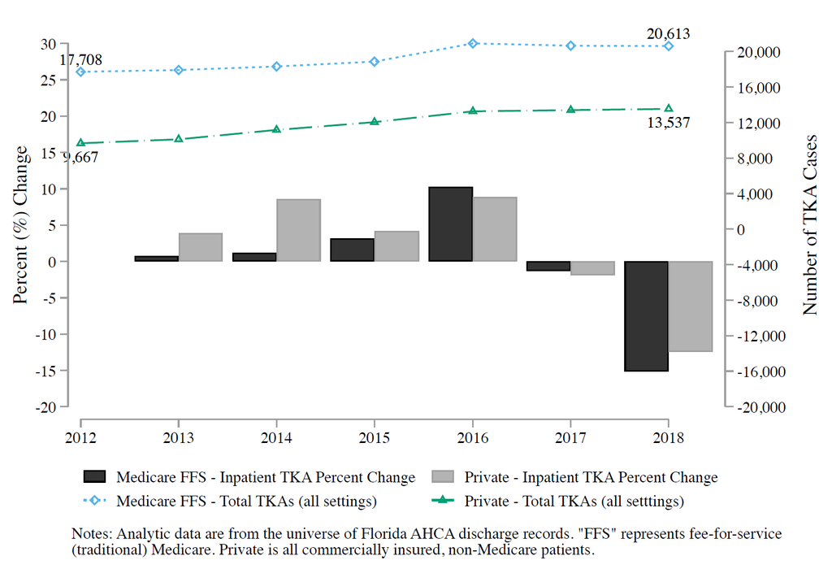

Inpatient TKA trends by payer

## TKA Outpatient Trends

**Near doubling** of privately-insured outpatient share

Physicians and hospitals rapidly adopted the new setting option

**Key insight:**

Payment policy shapes where care is delivered — both directly (Medicare) and indirectly (private market spillovers)

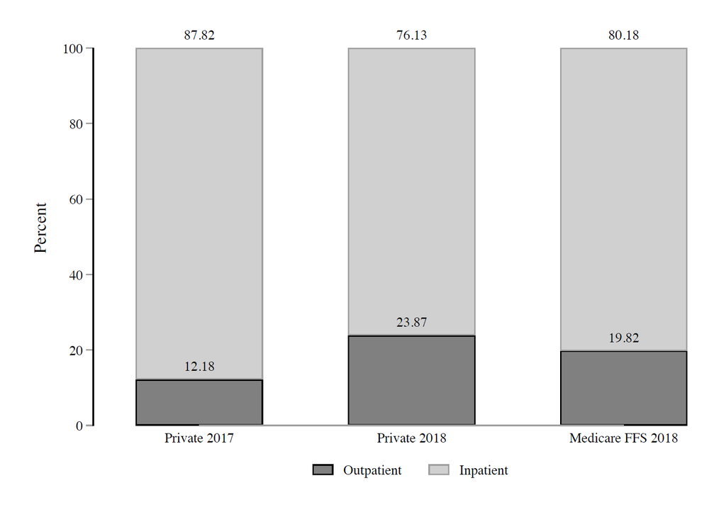

Setting allocation for TKA cases

## Vertical Integration and TKA Response

**Finding:**

- Non-VI physicians: **100% spike** in outpatient TKA
- VI physicians: **Much smaller response**

**Interpretation:**

- Vertically integrated physicians have different incentives
- Hospitals may prefer inpatient (higher revenue)
- VI physicians may be responding to hospital preferences

[figure not shown]

TKA trends by vertical integration status

## Vertical Integration: Deeper Evidence

**Research question:** What happens when hospitals acquire physicians?

**Setup:**

- Treatment: Physicians who become vertically integrated
- Control: Physicians who remain independent
- Examine post-acquisition changes

**Findings:**

- Outpatient procedures shift from ASCs to HOPDs
- 18% reduction in VI physicians ever using an ASC
- Charges increase (especially Medicare)
- Other hospitals don’t lose cases — ASCs close entirely

## How Vertical Integration Closes the Drawbridge

**Show R Code**

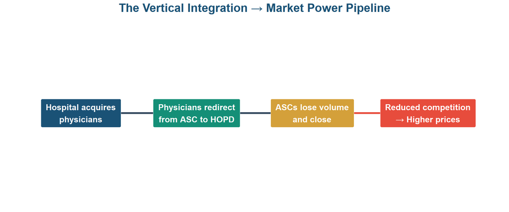

Figure 6: How vertical integration affects market structure

```r
# Create mechanism visualization
mechanism_data <- tibble(
  step = 1:4,
  description = c(
    "Hospital acquires\nphysicians",
    "Physicians redirect\nfrom ASC to HOPD",
    "ASCs lose volume\nand close",
    "Reduced competition\n→ Higher prices"
  ),
  x = c(1, 2, 3, 4),
  y = c(1, 1, 1, 1)
)

ggplot(mechanism_data, aes(x = x, y = y)) +
  geom_segment(aes(x = 1.3, xend = 1.7, y = 1, yend = 1),
               arrow = arrow(length = unit(0.3, "cm")), color = slate_gray, linewidth = 1.5) +
  geom_segment(aes(x = 2.3, xend = 2.7, y = 1, yend = 1),
               arrow = arrow(length = unit(0.3, "cm")), color = slate_gray, linewidth = 1.5) +
  geom_segment(aes(x = 3.3, xend = 3.7, y = 1, yend = 1),
               arrow = arrow(length = unit(0.3, "cm")), color = accent_coral, linewidth = 1.5) +
  geom_label(aes(label = description), fill = c(primary_blue, secondary_teal, warm_gold, accent_coral),
             color = "white", size = 5, fontface = "bold", label.padding = unit(0.5, "lines")) +
  coord_cartesian(xlim = c(0.5, 4.5), ylim = c(0.5, 1.5)) +
  labs(title = "The Vertical Integration → Market Power Pipeline") +
  theme_void() +
  theme(plot.title = element_text(color = primary_blue, face = "bold", size = 20, hjust = 0.5))
```

## Policy Implications

**The Bottom Line**

Vertical integration can be an **anticompetitive strategy** that:

- Redirects care to higher-cost settings
- Increases spending for public and private payers
- Reduces competition by eliminating ASCs
- Strains public finances (higher spending, lower tax collections)

**Policy toolkit:**

- Antitrust scrutiny of hospital-physician acquisitions
- Site-neutral payment policies
- Transparency requirements
- Support for independent practice settings

## From Private Markets to Public Policy

The moat determines private-market prices. But Medicare sits outside the moat — setting prices administratively. The question is whether Medicare’s prices spill over into the moated private market.

# The Government at the Gate

Medicare’s Shadow Over Private Markets

## Medicare Sets the Price — But the Moat Determines the Markup

**A Curious Feature of US Healthcare**

Medicare doesn’t just set prices for Medicare patients — it influences the entire market.

**Clemens & Gottlieb (2017):** “In the Shadow of a Giant”

- Medicare price changes spill over to private prices
- Private insurers often benchmark to Medicare rates
- Medicare effectively sets a “reference point” for the market

## Spillover Effects

**Key papers:**

| Paper | Finding |
| --- | --- |
| Richards & Tello-Trillo (2019) | Managed care contracting affects non-managed care patients |
| Barnett et al. (2020) | Medicare practices spill over to private patients |
| Geruso & Richards (2022) | Medicare’s treatment setting rules affect non-Medicare patients |

**Implication:**

Medicare policy is **not** just about Medicare patients. Changes ripple through the entire healthcare system.

**Graduate Students: Identifying Medicare Spillovers**

Clemens & Gottlieb (2017) use area-level Medicare fee changes (from geographic adjustments) as instruments for private prices. The key identifying assumption: Medicare fee changes are driven by bureaucratic formulas, not local market conditions.

# Key Takeaways

## Eight Lessons About Moats in Healthcare

### Physician Markets

1. Barriers to entry create market power
2. High IRR suggests monopoly rents
3. Incentives shape physician behavior
4. Practice style is malleable

### Hospital Markets

5. Volume-outcome relationship (teams matter)
6. Competition can backfire (medical arms race)
7. Prices are negotiated, not set
8. Consolidation usually raises prices

## The Moat Principle

**The Core Insight**

*“Every healthcare market is shaped by a moat — a barrier that controls who provides care, where it’s delivered, and at what price. The fundamental question of supply-side health economics is whether the moat protects patients or just profits.”*

**The policy challenge:**

How do we preserve the moats that protect quality while lowering the ones that only extract rents?

## Looking Ahead

The methods decks gave us the *tools* — IV, RDD, DiD. This deck gives us the *terrain* — the moats that define healthcare markets.

**Coming Up: You Become the Experts**

For the rest of the semester, *you* will be presenting papers that map the moats:

- **Physician markets:** How do incentives, licensing, and payment rules shape the physician moat?
- **Hospital markets:** How do pricing, competition, and consolidation reshape the fortress?
- **Vertical integration & PE:** What happens when moats merge — or when new players buy their way in?
- **Workforce & regulation:** Can policy lower the moat without sacrificing quality?
- **Pharmaceuticals:** The most profitable moat of all — patents, pricing, and innovation.

*As you read each paper, apply the Moat Test: Who built the moat, and who does it protect?*

## Discussion Questions

1. **Moat diagnosis:** Pick a healthcare provider type (dentist, pharmacist, physical therapist). What is their moat? How does it compare to physicians’? Would patients benefit from lowering it?
2. **Agency vs. incentives:** A hospital switches from fee-for-service to capitated payment for its employed physicians. Using the agency framework, predict what happens to utilization, quality, and physician income. Which patients benefit? Which are harmed?
3. **Consolidation tradeoffs:** A rural community has two hospitals that want to merge, arguing that consolidation will prevent both from closing. How would you evaluate this claim? What evidence would you need?
4. **The moat grows:** Private equity firms are increasingly acquiring physician practices and nursing homes. Using the moat framework, what market power concerns does this raise? How is PE consolidation different from hospital-physician vertical integration?